# QCPA - PCA

Flora Timney

2025-03-06

### Introduction

This script is to analyse the outputs of the QCPA framework included in the micaToolbox plugin of ImageJ. Preceding this analysis I created a Macro script to batch process a folder of images using QCPA (script called ‘1_FT_Batch_QCPA.ijm’) and a python script to combine the result outputs for each image into a single csv file (script called ‘Merge_csvs.py). Note, however, that this second part can be done directly in R as demonstrated in the ’QCPA Worked Example’ script downloadable from https://github.com/cedricvandenberg/QCPA-batch-script/tree/main)

### Set up

Initialise R environment, set working directory, clear workspace, load in functions and packages, and set plot theme.

```
## - The project is out-of-sync -- use `renv::status()` for details.
```

### 1. Load in and organise data

### 2. Compute PCA

```r
res.pca <- prcomp(normalised_data, scale = FALSE)
```

### 3. Visualisations

1. Correlation matrix

[figure not shown]

2. Scree plot visualise eigenvalues (scree plot). Show the percentage of variances explained by each principal component.

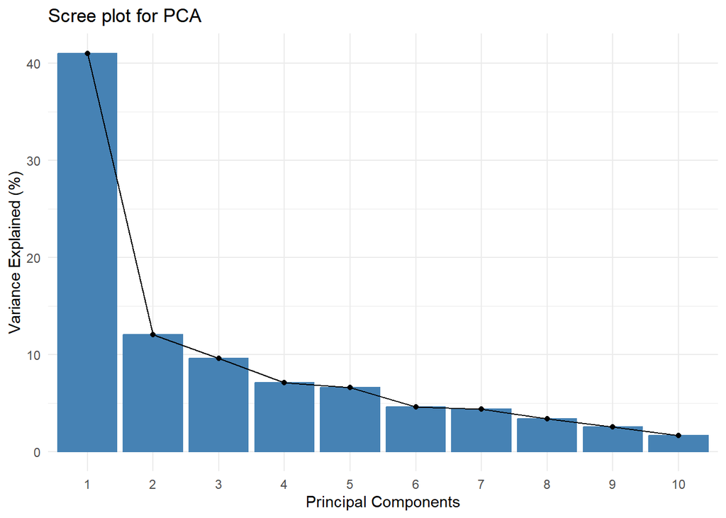

### 4. Accessing PCA results

### 5. Plotting

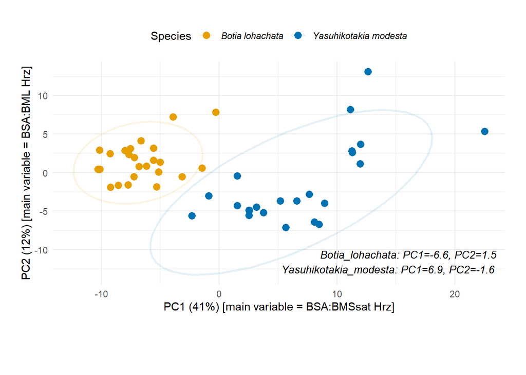

Extra notes: calculating PCA results for variables: coordinates, cos2 and contributions

var.coord = loadings * the component standard deviations var.cos2 = var.coord^2 var.contrib. The contribution of a variable to a given principal component is (in percentage) : (var.cos2 * 100) / (total cos2 of the component)

ind.coord = res.pca$x Cos2 of individuals. Two steps: Calculate the square distance between each individual and the PCA center of gravity: d2 = [(var1_ind_i - mean_var1)/sd_var1]^2 + …+ [(var10_ind_i - mean_var10)/sd_var10]^2 + …+.. Calculate the cos2 as ind.coord^2/d2 Contributions of individuals to the principal components: 100 * (1 / number_of_individuals)*(ind.coord^2 / comp_sdev^2). Note that the sum of all the contributions per column is 100